# PROBLEM STATEMENT : ( Tourism Project)

The company "Visit with us" is looking to expand its customer base by introducing a new Wellness Tourism Package. Currently, they offer five types of packages: Basic, Standard, Deluxe, Super Deluxe, and King. However, only 18% of customers purchased these packages last year, and identifying potential customers has been challenging due to random contact methods. Wellness Tourism focuses on promoting a healthy lifestyle and well-being. The Data Scientist is tasked with analyzing customer data to identify the right target audience for the new package. It is also expected to build a predictive model that will help forecast which customers are likely to purchase the new product, thus allowing the company to contact only those who show potential interest.

```python
import pandas as pd
import numpy as np
import matplotlib.pyplot as plt
import seaborn as sns
from sklearn.impute import SimpleImputer
from xgboost import XGBClassifier
from sklearn.model_selection import train_test_split
from sklearn.tree import DecisionTreeClassifier
from sklearn.ensemble import RandomForestClassifier, BaggingClassifier, AdaBoostClassifier, GradientBoostingClassifier
from sklearn.model_selection import GridSearchCV
from sklearn.metrics import accuracy_score, classification_report, confusion_matrix, f1_score, precision_score, recall_score
import warnings
warnings.filterwarnings('ignore')
```

```python
from google.colab import drive
drive.mount('/content/drive')
data = pd.read_excel("/content/drive/MyDrive/Tourism (2).xlsx")
df = data
df.head(5)
```

|  | CustomerID | ProdTaken | Age | TypeofContact | CityTier | DurationOfPitch | Occupation | Gender | NumberOfPersonVisiting | NumberOfFollowups | ProductPitched | PreferredPropertyStar | MaritalStatus | NumberOfTrips | Passport | PitchSatisfactionScore | OwnCar | NumberOfChildrenVisiting | Designation | MonthlyIncome |
| --- | --- | --- | --- | --- | --- | --- | --- | --- | --- | --- | --- | --- | --- | --- | --- | --- | --- | --- | --- | --- |
| 0 | 200000 | 1 | 41.0 | Self Enquiry | 3 | 6.0 | Salaried | Female | 3 | 3.0 | Deluxe | 3.0 | Single | 1.0 | 1 | 2 | 1 | 0.0 | Manager | 20993.0 |
| 1 | 200001 | 0 | 49.0 | Company Invited | 1 | 14.0 | Salaried | Male | 3 | 4.0 | Deluxe | 4.0 | Divorced | 2.0 | 0 | 3 | 1 | 2.0 | Manager | 20130.0 |
| 2 | 200002 | 1 | 37.0 | Self Enquiry | 1 | 8.0 | Free Lancer | Male | 3 | 4.0 | Basic | 3.0 | Single | 7.0 | 1 | 3 | 0 | 0.0 | Executive | 17090.0 |
| 3 | 200003 | 0 | 33.0 | Company Invited | 1 | 9.0 | Salaried | Female | 2 | 3.0 | Basic | 3.0 | Divorced | 2.0 | 1 | 5 | 1 | 1.0 | Executive | 17909.0 |
| 4 | 200004 | 0 | NaN | Self Enquiry | 1 | 8.0 | Small Business | Male | 2 | 3.0 | Basic | 4.0 | Divorced | 1.0 | 0 | 5 | 1 | 0.0 | Executive | 18468.0 |

**Checking the shape of the dataset :**

```python
df.shape
```

```
(4888, 20)
```

The data has 4888 rows and 20 columns

**Checking the data types of the columns for the dataset :**

```python
data.dtypes
```

|  | 0 |
| --- | --- |
| CustomerID | int64 |
| ProdTaken | int64 |
| Age | float64 |
| TypeofContact | object |
| CityTier | int64 |
| DurationOfPitch | float64 |
| Occupation | object |
| Gender | object |
| NumberOfPersonVisiting | int64 |
| NumberOfFollowups | float64 |
| ProductPitched | object |
| PreferredPropertyStar | float64 |
| MaritalStatus | object |
| NumberOfTrips | float64 |
| Passport | int64 |
| PitchSatisfactionScore | int64 |
| OwnCar | int64 |
| NumberOfChildrenVisiting | float64 |
| Designation | object |
| MonthlyIncome | float64 |

**dtype:** object

**Checking for missing values and duplicate values :**

```python
#checking number of null values
print(' ' ,df.isnull().sum())
#checking duplicate values
print("")
print(' The no.of duplicated values are ' ,df.duplicated().sum())
# Calculating the percentage of missing values for each column
missing_percentage = df.isnull().sum() / len(df) * 100
# Printing the result
print(missing_percentage)
# Calculating the number of unique values for each column
unique_values = df.nunique()
# Printing the result
print(unique_values)
```

```
  CustomerID                    0
ProdTaken                     0
Age                         226
TypeofContact                25
CityTier                      0
DurationOfPitch             251
Occupation                    0
Gender                        0
NumberOfPersonVisiting        0
NumberOfFollowups            45
ProductPitched                0
PreferredPropertyStar        26
MaritalStatus                 0
NumberOfTrips               140
Passport                      0
PitchSatisfactionScore        0
OwnCar                        0
NumberOfChildrenVisiting     66
Designation                   0
MonthlyIncome               233
dtype: int64

 The no.of duplicated values are  0
CustomerID                  0.000000
ProdTaken                   0.000000
Age                         4.623568
TypeofContact               0.511457
CityTier                    0.000000
DurationOfPitch             5.135025
Occupation                  0.000000
Gender                      0.000000
NumberOfPersonVisiting      0.000000
NumberOfFollowups           0.920622
ProductPitched              0.000000
PreferredPropertyStar       0.531915
MaritalStatus               0.000000
NumberOfTrips               2.864157
Passport                    0.000000
PitchSatisfactionScore      0.000000
OwnCar                      0.000000
```

[output cut: 10 more lines]

```
Occupation                     4
Gender                         3
NumberOfPersonVisiting         5
NumberOfFollowups              6
ProductPitched                 5
PreferredPropertyStar          3
MaritalStatus                  4
NumberOfTrips                 12
Passport                       2
PitchSatisfactionScore         5
OwnCar                         2
NumberOfChildrenVisiting       4
Designation                    5
MonthlyIncome               2475
dtype: int64
```

**Statistical summary of the data :**

```python
df.describe()
```

|  | CustomerID | ProdTaken | Age | CityTier | DurationOfPitch | NumberOfPersonVisiting | NumberOfFollowups | PreferredPropertyStar | NumberOfTrips | Passport | PitchSatisfactionScore | OwnCar | NumberOfChildrenVisiting | MonthlyIncome |
| --- | --- | --- | --- | --- | --- | --- | --- | --- | --- | --- | --- | --- | --- | --- |
| count | 4888.000000 | 4888.000000 | 4662.000000 | 4888.000000 | 4637.000000 | 4888.000000 | 4843.000000 | 4862.000000 | 4748.000000 | 4888.000000 | 4888.000000 | 4888.000000 | 4822.000000 | 4655.000000 |
| mean | 202443.500000 | 0.188216 | 37.622265 | 1.654255 | 15.490835 | 2.905074 | 3.708445 | 3.581037 | 3.236521 | 0.290917 | 3.078151 | 0.620295 | 1.187267 | 23619.853491 |
| std | 1411.188388 | 0.390925 | 9.316387 | 0.916583 | 8.519643 | 0.724891 | 1.002509 | 0.798009 | 1.849019 | 0.454232 | 1.365792 | 0.485363 | 0.857861 | 5380.698361 |
| min | 200000.000000 | 0.000000 | 18.000000 | 1.000000 | 5.000000 | 1.000000 | 1.000000 | 3.000000 | 1.000000 | 0.000000 | 1.000000 | 0.000000 | 0.000000 | 1000.000000 |
| 25% | 201221.750000 | 0.000000 | 31.000000 | 1.000000 | 9.000000 | 2.000000 | 3.000000 | 3.000000 | 2.000000 | 0.000000 | 2.000000 | 0.000000 | 1.000000 | 20346.000000 |
| 50% | 202443.500000 | 0.000000 | 36.000000 | 1.000000 | 13.000000 | 3.000000 | 4.000000 | 3.000000 | 3.000000 | 0.000000 | 3.000000 | 1.000000 | 1.000000 | 22347.000000 |
| 75% | 203665.250000 | 0.000000 | 44.000000 | 3.000000 | 20.000000 | 3.000000 | 4.000000 | 4.000000 | 4.000000 | 1.000000 | 4.000000 | 1.000000 | 2.000000 | 25571.000000 |
| max | 204887.000000 | 1.000000 | 61.000000 | 3.000000 | 127.000000 | 5.000000 | 6.000000 | 5.000000 | 22.000000 | 1.000000 | 5.000000 | 1.000000 | 3.000000 | 98678.000000 |

```python
# Grouping by Designation and calculating the mean of MonthlyIncome
avg_income_by_designation = df.groupby('Designation')['MonthlyIncome'].mean()
# Print the result
print(avg_income_by_designation)
```

```
Designation
AVP               32241.046784
Executive         19939.922507
Manager           22643.157629
Senior Manager    26637.749326
VP                35878.947826
Name: MonthlyIncome, dtype: float64
```

```python
# Dropping the 'CustomerID' column
df = df.drop(columns=['CustomerID'])
# Printing the updated DataFrame
print(df)
```

```
      ProdTaken   Age    TypeofContact  CityTier  DurationOfPitch  \
0             1  41.0     Self Enquiry         3              6.0
1             0  49.0  Company Invited         1             14.0
2             1  37.0     Self Enquiry         1              8.0
3             0  33.0  Company Invited         1              9.0
4             0   NaN     Self Enquiry         1              8.0
...         ...   ...              ...       ...              ...
4883          1  49.0     Self Enquiry         3              9.0
4884          1  28.0  Company Invited         1             31.0
4885          1  52.0     Self Enquiry         3             17.0
4886          1  19.0     Self Enquiry         3             16.0
4887          1  36.0     Self Enquiry         1             14.0

          Occupation  Gender  NumberOfPersonVisiting  NumberOfFollowups  \
0           Salaried  Female                       3                3.0
```

[output cut: 51 more lines]

```python
# Counting the unique categories in each categorical variable
categorical_columns = ['Designation', 'TypeofContact']
category_counts = {col: df[col].value_counts() for col in categorical_columns}
# Printing the result
for col, count in category_counts.items():
    print(f"Category counts for {col}:")
    print(count)
    print()
```

```
Category counts for Designation:
Designation
Executive         1842
Manager           1732
Senior Manager     742
AVP                342
VP                 230
Name: count, dtype: int64

Category counts for TypeofContact:
TypeofContact
Self Enquiry       3444
Company Invited    1419
Name: count, dtype: int64
```

```python
#Check unique values in categorical columns
print("Unique values in Designation:")
print(df['Designation'].value_counts())
print("\nUnique values in TypeofContact:")
print(df['TypeofContact'].value_counts())
#Identify any unexpected or anomalous values
# Impute unexpected values with the most frequent category
df['Designation'] = df['Designation'].replace(['InvalidDesignation'], df['Designation'].mode()[0])  # Replace any unexpected value in Designation with the most frequent value
df['TypeofContact'] = df['TypeofContact'].replace(['InvalidContactType'], df['TypeofContact'].mode()[0])  # Replace any unexpected value in TypeofContact with the most frequent value
# Printing the cleaned data
print("\nCleaned Designation column:")
print(df['Designation'].value_counts())
print("\nCleaned TypeofContact column:")
print(df['TypeofContact'].value_counts())
```

```
Unique values in Designation:
Designation
Executive         1842
Manager           1732
Senior Manager     742
AVP                342
VP                 230
Name: count, dtype: int64

Unique values in TypeofContact:
TypeofContact
Self Enquiry       3444
Company Invited    1419
Name: count, dtype: int64

Cleaned Designation column:
Designation
Executive         1842
Manager           1732
Senior Manager     742
AVP                342
VP                 230
Name: count, dtype: int64

Cleaned TypeofContact column:
TypeofContact
Self Enquiry       3444
Company Invited    1419
Name: count, dtype: int64
```

```python
# Converting categorical variables to 'category' data type
df['Designation'] = df['Designation'].astype('category')
df['TypeofContact'] = df['TypeofContact'].astype('category')
# Printing the updated data types to confirm
print(df.dtypes)
```

```
ProdTaken                      int64
Age                          float64
TypeofContact               category
CityTier                       int64
DurationOfPitch              float64
Occupation                    object
Gender                        object
NumberOfPersonVisiting         int64
NumberOfFollowups            float64
ProductPitched                object
PreferredPropertyStar        float64
MaritalStatus                 object
NumberOfTrips                float64
Passport                       int64
PitchSatisfactionScore         int64
OwnCar                         int64
NumberOfChildrenVisiting     float64
Designation                 category
MonthlyIncome                float64
dtype: object
```

**PERFORMING EDA TO ANALYSE THE DATA :**

```python
# Create a copy of the prepared data
df_copy = df.copy()
# Printing the first few rows of the copied data to confirm
print(df_copy.head())
```

```
   ProdTaken   Age    TypeofContact  CityTier  DurationOfPitch  \
0          1  41.0     Self Enquiry         3              6.0
1          0  49.0  Company Invited         1             14.0
2          1  37.0     Self Enquiry         1              8.0
3          0  33.0  Company Invited         1              9.0
4          0   NaN     Self Enquiry         1              8.0

       Occupation  Gender  NumberOfPersonVisiting  NumberOfFollowups  \
0        Salaried  Female                       3                3.0
1        Salaried    Male                       3                4.0
2     Free Lancer    Male                       3                4.0
3        Salaried  Female                       2                3.0
4  Small Business    Male                       2                3.0

  ProductPitched  PreferredPropertyStar MaritalStatus  NumberOfTrips  \
```

[output cut: 19 more lines]

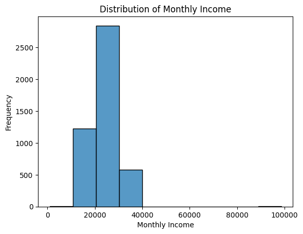

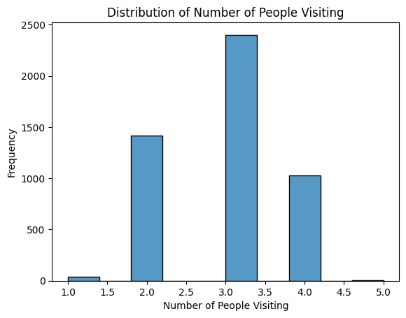

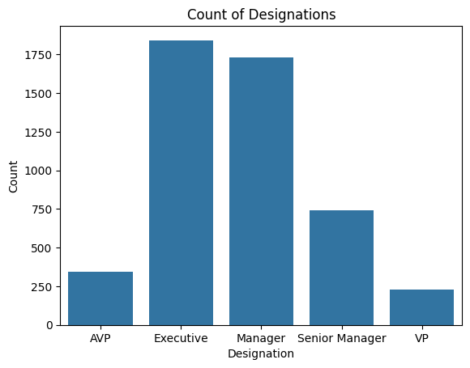

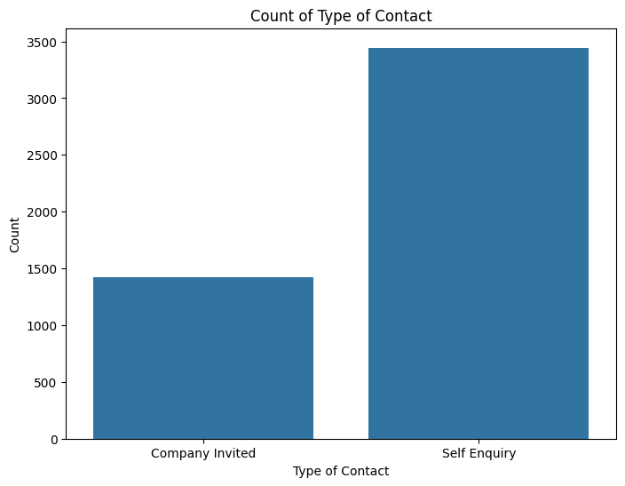

```python
# Univariate Analysis of Numerical Data( Monthly Income)
# Plotting histogram for MonthlyIncome
sns.histplot(df['MonthlyIncome'], bins=10)
plt.title("Distribution of Monthly Income")
plt.xlabel("Monthly Income")
plt.ylabel("Frequency")
plt.show()
print(' ')
# Plotting histogram for NumberOfPersonVisiting
sns.histplot(df['NumberOfPersonVisiting'],bins=10)
plt.title("Distribution of Number of People Visiting")
plt.xlabel("Number of People Visiting")
plt.ylabel("Frequency")
plt.show()
print(" ")
# Univariate Analysis of Categorical Data (Designation)
# Plotting bar chart for Designation
sns.countplot(data=df, x='Designation')
plt.title("Count of Designations")
plt.xlabel("Designation")
plt.ylabel("Count")
plt.show()
print('')
#Univariate Analysis of Categorical Data (e.g., TypeofContact)
# Plotting bar chart for TypeofContact
plt.figure(figsize=(8,6))
sns.countplot(data=df, x='TypeofContact')
plt.title("Count of Type of Contact")
plt.xlabel("Type of Contact")
plt.ylabel("Count")
plt.show()
```

```python
#Examine the outliers using IQR (Interquartile Range)
Q1 = df['NumberOfPersonVisiting'].quantile(0.25)
Q3 = df['NumberOfPersonVisiting'].quantile(0.75)
IQR = Q3 - Q1
# Calculate the lower and upper bounds
lower_bound = Q1 - 1.5 * IQR
upper_bound = Q3 + 1.5 * IQR
print(f"Lower Bound: {lower_bound}")
print(f"Upper Bound: {upper_bound}")
#Identify the outliers
outliers = df[(df['NumberOfPersonVisiting'] < lower_bound) | (df['NumberOfPersonVisiting'] > upper_bound)]
print("\nOutliers in NumberOfPersonVisiting:")
print(outliers)
#Impute the outliers with the median (or another method like capping)
# You can choose median, mean, or cap them at the lower or upper bound
median_value = df['NumberOfPersonVisiting'].median()
# Imputing the outliers with the median value
df['NumberOfPersonVisiting'] = np.where((df['NumberOfPersonVisiting'] < lower_bound) | (df['NumberOfPersonVisiting'] > upper_bound), median_value, df['NumberOfPersonVisiting'])
# Display the data after imputation
print("\nData after imputing the outliers:")
print(df)
```

```
Lower Bound: 0.5
Upper Bound: 4.5

Outliers in NumberOfPersonVisiting:
      ProdTaken   Age TypeofContact  CityTier  DurationOfPitch  \
3977          0  60.0  Self Enquiry         3             32.0
4002          0  31.0  Self Enquiry         1              9.0
4105          0  28.0  Self Enquiry         1             16.0

          Occupation   Gender  NumberOfPersonVisiting  NumberOfFollowups  \
3977        Salaried  Fe Male                       5                4.0
4002        Salaried     Male                       5                5.0
4105  Small Business   Female                       5                4.0

     ProductPitched  PreferredPropertyStar MaritalStatus  NumberOfTrips  \
3977       Standard                    5.0     Unmarried            2.0
4002         Deluxe                    3.0       Married            3.0
4105          Basic                    4.0        Single            3.0

      Passport  PitchSatisfactionScore  OwnCar  NumberOfChildrenVisiting  \
3977         0                       3       1                       2.0
4002         0                       4       1                       2.0
4105         0                       3       0                       2.0

         Designation  MonthlyIncome
3977  Senior Manager        26315.0
4002         Manager        22830.0
4105       Executive        20957.0

Data after imputing the outliers:
      ProdTaken   Age    TypeofContact  CityTier  DurationOfPitch  \
0             1  41.0     Self Enquiry         3              6.0
1             0  49.0  Company Invited         1             14.0
2             1  37.0     Self Enquiry         1              8.0
3             0  33.0  Company Invited         1              9.0
4             0   NaN     Self Enquiry         1              8.0
...         ...   ...              ...       ...              ...
4883          1  49.0     Self Enquiry         3              9.0
4884          1  28.0  Company Invited         1             31.0
4885          1  52.0     Self Enquiry         3             17.0
```

[output cut: 41 more lines]

```

         Designation  MonthlyIncome
0            Manager        20993.0
1            Manager        20130.0
2          Executive        17090.0
3          Executive        17909.0
4          Executive        18468.0
...              ...            ...
4883         Manager        26576.0
4884       Executive        21212.0
4885  Senior Manager        31820.0
4886       Executive        20289.0
4887       Executive        24041.0

[4888 rows x 19 columns]
```

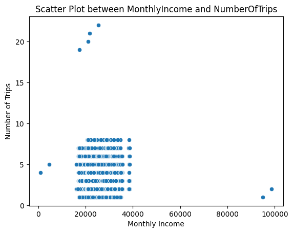

```
Correlation Matrix between MonthlyIncome and NumberOfTrips:
               MonthlyIncome  NumberOfTrips
MonthlyIncome       1.000000       0.139105
NumberOfTrips       0.139105       1.000000
```

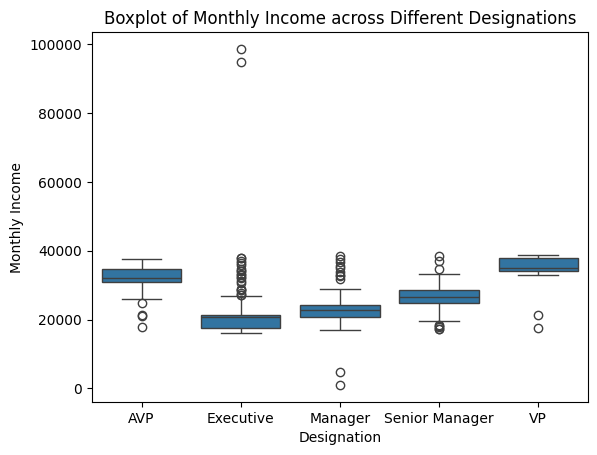

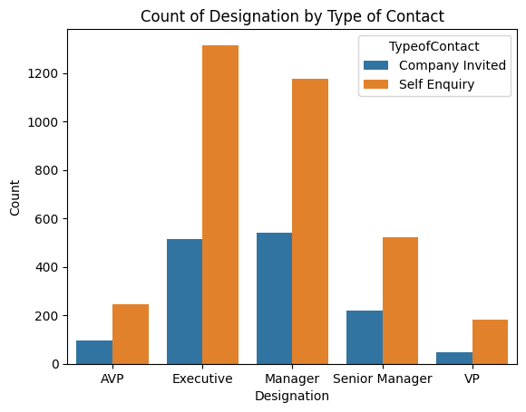

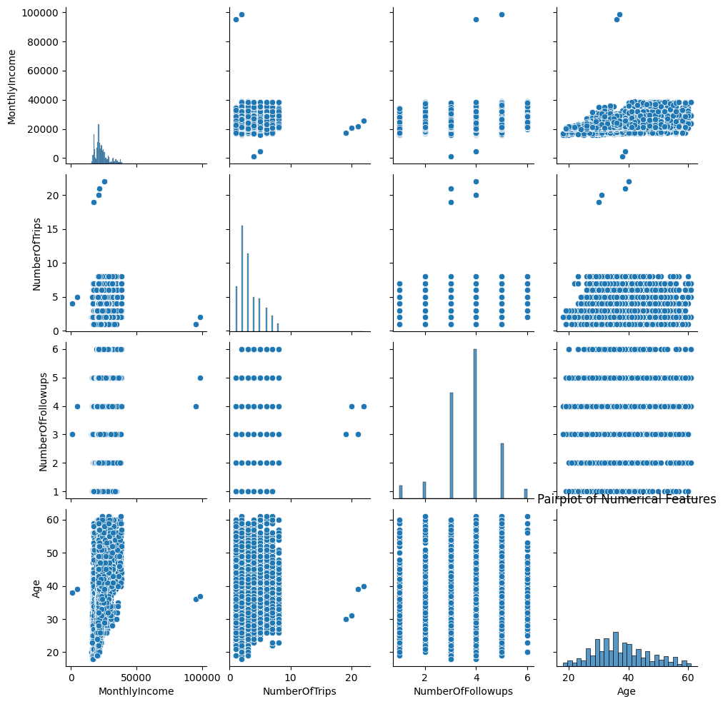

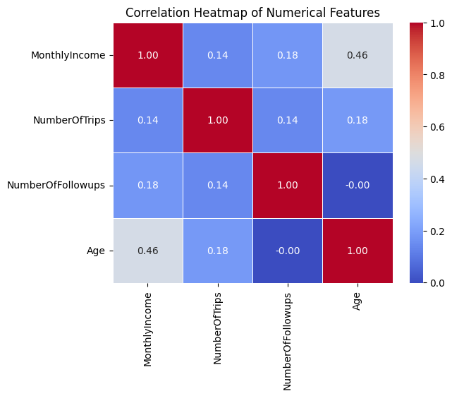

```
Average Monthly Income by Designation:
      Designation  MonthlyIncome
0             AVP   32241.046784
1       Executive   19939.922507
2         Manager   22643.157629
3  Senior Manager   26637.749326
4              VP   35878.947826
```

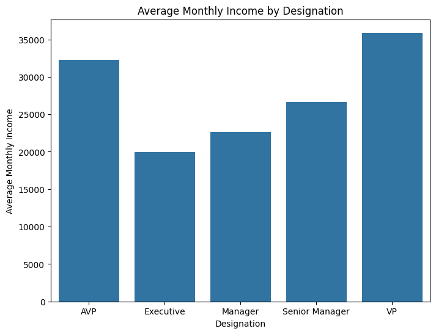

```python
#Bivariate Analysis - Numerical vs Numerical (e.g., MonthlyIncome vs NumberOfTrips)
sns.scatterplot(data=df, x='MonthlyIncome', y='NumberOfTrips')
plt.title('Scatter Plot between MonthlyIncome and NumberOfTrips')
plt.xlabel('Monthly Income')
plt.ylabel('Number of Trips')
plt.show()
# Correlation Coefficient between MonthlyIncome and NumberOfTrips
correlation = df[['MonthlyIncome', 'NumberOfTrips']].corr()
print("\nCorrelation Matrix between MonthlyIncome and NumberOfTrips:")
print(correlation)
#Bivariate Analysis - Numerical vs Categorical (e.g., MonthlyIncome vs Designation)
sns.boxplot(x='Designation', y='MonthlyIncome', data=df)
plt.title('Boxplot of Monthly Income across Different Designations')
plt.xlabel('Designation')
plt.ylabel('Monthly Income')
plt.show()
#Bivariate Analysis - Categorical vs Categorical (TypeofContact vs Designation)
sns.countplot(data=df, x='Designation', hue='TypeofContact')
plt.title('Count of Designation by Type of Contact')
plt.xlabel('Designation')
plt.ylabel('Count')
plt.show()
#Multivariate Analysis - Pairplot of numerical features
numerical_cols = ['MonthlyIncome', 'NumberOfTrips', 'NumberOfFollowups', 'Age']
sns.pairplot(df[numerical_cols])
plt.title('Pairplot of Numerical Features')
plt.show()
#Multivariate Analysis - Correlation Heatmap
correlation_matrix = df[numerical_cols].corr()
sns.heatmap(correlation_matrix, annot=True, cmap='coolwarm', fmt='.2f', linewidths=0.5)
plt.title('Correlation Heatmap of Numerical Features')
plt.show()
# 6. Multivariate Analysis - Group by Designation and calculate the mean of MonthlyIncome
designation_income = df.groupby('Designation')['MonthlyIncome'].mean().reset_index()
print("\nAverage Monthly Income by Designation:")
print(designation_income)
# Plotting the results
plt.figure(figsize=(8,6))
sns.barplot(data=designation_income, x='Designation', y='MonthlyIncome')
plt.title('Average Monthly Income by Designation')
plt.xlabel('Designation')
plt.ylabel('Average Monthly Income')
plt.show()
```

~**The scatter plot and correlation matrix will help us understand if two numerical features are related**.

~**Boxplots for numerical vs categorical variables help in understanding the spread and central tendency of numerical features across different categories.**

~**Multivariate analysis provides deeper insights into how multiple variables interact, which can be useful for model building.**

```python
# Grouping data by 'ProdTaken' (the packages)
package_group = df.groupby('ProdTaken').agg(
    Age_mean=('Age', 'mean'),
    Age_median=('Age', 'median'),
    Age_std=('Age', 'std'),
    MonthlyIncome_mean=('MonthlyIncome', 'mean'),
    MonthlyIncome_median=('MonthlyIncome', 'median'),
    MonthlyIncome_std=('MonthlyIncome', 'std'),
    NumberOfTrips_mean=('NumberOfTrips', 'mean'),
    NumberOfTrips_median=('NumberOfTrips', 'median'),
    NumberOfTrips_std=('NumberOfTrips', 'std'),
    NumberOfFollowups_mean=('NumberOfFollowups', 'mean'),
    NumberOfFollowups_median=('NumberOfFollowups', 'median'),
    NumberOfFollowups_std=('NumberOfFollowups', 'std'))
# Print the summary statistics of each package
print(package_group)
# Optionally, you can also analyze the count of each product taken
package_count = df['ProdTaken'].value_counts()
print("\nCount of each product taken by customers:")
print(package_count)
```

```
            Age_mean  Age_median    Age_std  MonthlyIncome_mean  \
ProdTaken
0          38.282092        37.0   9.007215        23960.962835
1          34.770548        33.0  10.068501        22172.827703

           MonthlyIncome_median  MonthlyIncome_std  NumberOfTrips_mean  \
ProdTaken
0                       22729.0        5484.359516            3.219531
1                       21172.0        4648.893747            3.308370

           NumberOfTrips_median  NumberOfTrips_std  NumberOfFollowups_mean  \
ProdTaken
0                           3.0           1.798377                3.654286
1                           3.0           2.048921                3.941886

           NumberOfFollowups_median  NumberOfFollowups_std
ProdTaken
0                               4.0               0.993769
1                               4.0               1.007066

Count of each product taken by customers:
ProdTaken
0    3968
1     920
Name: count, dtype: int64
```

**Observations:**

**NumberOfTrips:** we can compare how frequently people who purchased different packages travel. Those who purchase more expensive packages might take more trips overall.

**NumberOfFollowups:** This could indicate how often customers needed to be followed up with in the sales process. A higher number of follow-ups might indicate that customers purchasing certain packages are harder to convert.

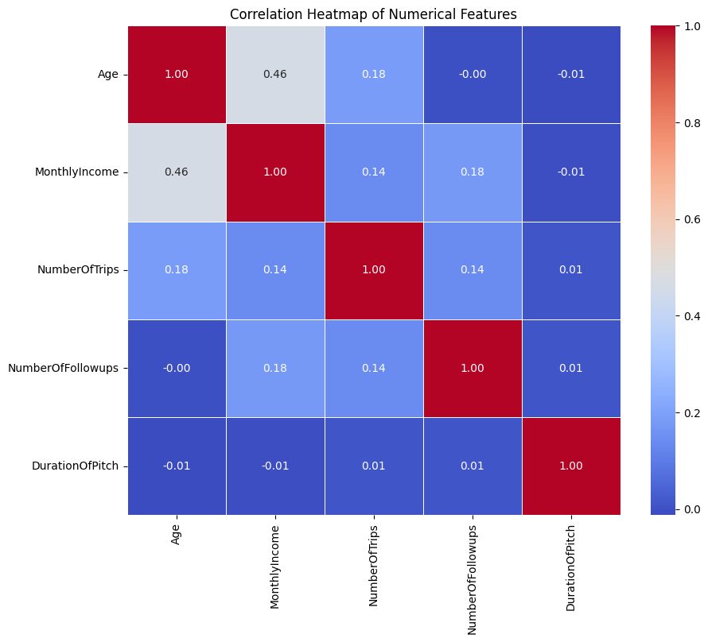

```python
# Select numerical columns from the dataframe
numerical_cols = ['Age', 'MonthlyIncome', 'NumberOfTrips', 'NumberOfFollowups', 'DurationOfPitch']
# Compute the correlation matrix for numerical columns
correlation_matrix = df[numerical_cols].corr()
# Plotting the heatmap
plt.figure(figsize=(10, 8))
sns.heatmap(correlation_matrix, annot=True, cmap='coolwarm', fmt='.2f', linewidths=0.5)
plt.title('Correlation Heatmap of Numerical Features')
plt.show()
```

**Model building** :

```python
# Define the columns to drop (customer interaction related columns)
drop_columns = ['TypeofContact', 'DurationOfPitch', 'NumberOfFollowups', 'PitchSatisfactionScore']
X = df.drop(columns=drop_columns + ['ProdTaken'])
Y = df['ProdTaken']
# Check the shapes of X and Y
print("Shape of X:", X.shape)
print("Shape of Y:", Y.shape)
```

```
Shape of X: (4888, 14)
Shape of Y: (4888,)
```

```python
# Impute numerical columns with median
numerical_cols = X.select_dtypes(include=['float64', 'int64']).columns
numerical_imputer = SimpleImputer(strategy='median')
X[numerical_cols] = numerical_imputer.fit_transform(X[numerical_cols])
# Impute categorical columns with mode
categorical_cols = X.select_dtypes(include=['category', 'object']).columns
categorical_imputer = SimpleImputer(strategy='most_frequent')
X[categorical_cols] = categorical_imputer.fit_transform(X[categorical_cols])
print(X.isnull().sum())
```

```
Age                         0
CityTier                    0
Occupation                  0
Gender                      0
NumberOfPersonVisiting      0
ProductPitched              0
PreferredPropertyStar       0
MaritalStatus               0
NumberOfTrips               0
Passport                    0
OwnCar                      0
NumberOfChildrenVisiting    0
Designation                 0
MonthlyIncome               0
dtype: int64
```

```python
# Create dummy variables for categorical string type columns
X = pd.get_dummies(X, drop_first=True)
# Convert columns back to float
X = X.astype(float)
# Verify the changes
print(X.dtypes)
```

```
Age                            float64
CityTier                       float64
NumberOfPersonVisiting         float64
PreferredPropertyStar          float64
NumberOfTrips                  float64
Passport                       float64
OwnCar                         float64
NumberOfChildrenVisiting       float64
MonthlyIncome                  float64
Occupation_Large Business      float64
Occupation_Salaried            float64
Occupation_Small Business      float64
Gender_Female                  float64
Gender_Male                    float64
ProductPitched_Deluxe          float64
ProductPitched_King            float64
ProductPitched_Standard        float64
ProductPitched_Super Deluxe    float64
MaritalStatus_Married          float64
MaritalStatus_Single           float64
MaritalStatus_Unmarried        float64
Designation_Executive          float64
Designation_Manager            float64
Designation_Senior Manager     float64
Designation_VP                 float64
dtype: object
```

```python
# Split the dataset into training and testing sets
X_train, X_test, Y_train, Y_test = train_test_split(X, Y, test_size=0.3, random_state=42)
print("Shape of X_train:", X_train.shape)
print("Shape of X_test:", X_test.shape)
print("Shape of Y_train:", Y_train.shape)
print("Shape of Y_test:", Y_test.shape)
```

```
Shape of X_train: (3421, 25)
Shape of X_test: (1467, 25)
Shape of Y_train: (3421,)
Shape of Y_test: (1467,)
```

**Building the Decision Tree Classifier and Print Performance Metrics**

```python
# Initialize the Decision Tree classifier
dt_classifier = DecisionTreeClassifier(random_state=42)
# Fit the model on training data
dt_classifier.fit(X_train, Y_train)
# Predict on the test set
Y_pred = dt_classifier.predict(X_test)
# Evaluate the performance
accuracy = accuracy_score(Y_test, Y_pred)
classification_rep = classification_report(Y_test, Y_pred)
conf_matrix = confusion_matrix(Y_test, Y_pred)
print("Accuracy:", accuracy)
print("Classification Report:\n", classification_rep)
print("Confusion Matrix:\n", conf_matrix)
```

```
Accuracy: 0.8820722563053851
Classification Report:
               precision    recall  f1-score   support

           0       0.93      0.93      0.93      1193
           1       0.69      0.68      0.68       274

    accuracy                           0.88      1467
   macro avg       0.81      0.80      0.80      1467
weighted avg       0.88      0.88      0.88      1467

Confusion Matrix:
 [[1109   84]
 [  89  185]]
```

**Cost Complexity Pruning for Decision Tree**

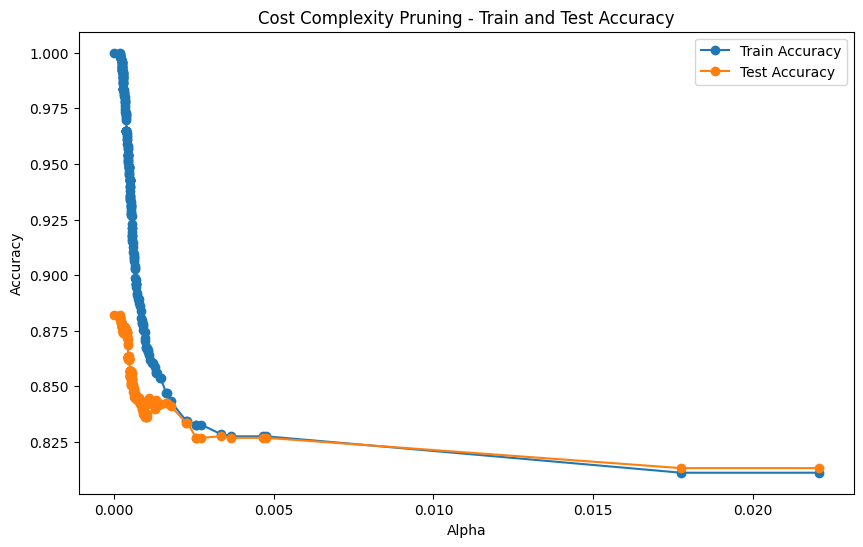

```
Best alpha: 0.0
```

```python
path = dt_classifier.cost_complexity_pruning_path(X_train, Y_train)
ccp_alphas = path.ccp_alphas
impurities = path.impurities
train_accuracies = []
test_accuracies = []
for alpha in ccp_alphas:
    dt_pruned = DecisionTreeClassifier(random_state=42, ccp_alpha=alpha)
    dt_pruned.fit(X_train, Y_train)
    train_accuracies.append(dt_pruned.score(X_train, Y_train))
    test_accuracies.append(dt_pruned.score(X_test, Y_test))
plt.figure(figsize=(10, 6))
plt.plot(ccp_alphas, train_accuracies, label="Train Accuracy", marker='o')
plt.plot(ccp_alphas, test_accuracies, label="Test Accuracy", marker='o')
plt.xlabel('Alpha')
plt.ylabel('Accuracy')
plt.title('Cost Complexity Pruning - Train and Test Accuracy')
plt.legend()
plt.show()
best_alpha = ccp_alphas[np.argmax(test_accuracies)]
print(f"Best alpha: {best_alpha}")
```

**Hyperparameter Tuning for Decision Tree**

```python
# Hyperparameter grid for Decision Tree
param_grid = {
    'max_depth': [3, 5, 7, 10, None],
    'min_samples_split': [2, 5, 10],
    'min_samples_leaf': [1, 2, 4],
    'max_features': [None, 'sqrt', 'log2']
}
# Initialising GridSearchCV for Decision Tree
grid_search = GridSearchCV(DecisionTreeClassifier(random_state=42), param_grid, cv=5, n_jobs=-1, scoring='accuracy')
grid_search.fit(X_train, Y_train)
best_params = grid_search.best_params_
best_score = grid_search.best_score_
print("Best Parameters:", best_params)
print("Best Cross-Validation Score:", best_score)
```

```
Best Parameters: {'max_depth': 10, 'max_features': None, 'min_samples_leaf': 1, 'min_samples_split': 2}
Best Cross-Validation Score: 0.8430268493618476
```

**Classification Metrics and Observations** :

```python
dt_best = DecisionTreeClassifier(random_state=42, **best_params)
dt_best.fit(X_train, Y_train)
Y_pred_best = dt_best.predict(X_test)
classification_rep_best = classification_report(Y_test, Y_pred_best)
conf_matrix_best = confusion_matrix(Y_test, Y_pred_best)
print("Classification Report for Best Model:\n", classification_rep_best)
print("Confusion Matrix for Best Model:\n", conf_matrix_best)
```

```
Classification Report for Best Model:
               precision    recall  f1-score   support

           0       0.89      0.96      0.92      1193
           1       0.71      0.46      0.56       274

    accuracy                           0.86      1467
   macro avg       0.80      0.71      0.74      1467
weighted avg       0.85      0.86      0.85      1467

Confusion Matrix for Best Model:
 [[1141   52]
 [ 148  126]]
```

# Observation :

~ **Performance Metrics**: The classification report shows how well the model predicts each class .

**Building and Evaluating XGBoost Classifier** :

```python
xgb_classifier = XGBClassifier(random_state=42, use_label_encoder=False, eval_metric='logloss')
xgb_classifier.fit(X_train, Y_train)
Y_pred_xgb = xgb_classifier.predict(X_test)
accuracy_xgb = accuracy_score(Y_test, Y_pred_xgb)
classification_rep_xgb = classification_report(Y_test, Y_pred_xgb)
conf_matrix_xgb = confusion_matrix(Y_test, Y_pred_xgb)
print("Accuracy:", accuracy_xgb)
print("\nClassification Report:\n", classification_rep_xgb)
print("\nConfusion Matrix:\n", conf_matrix_xgb)
```

```
Accuracy: 0.885480572597137

Classification Report:
               precision    recall  f1-score   support

           0       0.90      0.96      0.93      1193
           1       0.78      0.54      0.64       274

    accuracy                           0.89      1467
   macro avg       0.84      0.75      0.79      1467
weighted avg       0.88      0.89      0.88      1467


Confusion Matrix:
 [[1150   43]
 [ 125  149]]
```

```python
dt_classifier = DecisionTreeClassifier(random_state=42)
rf_classifier = RandomForestClassifier(random_state=42)
bagging_classifier = BaggingClassifier(random_state=42)
ada_boost_classifier = AdaBoostClassifier(random_state=42)
gradient_boosting_classifier = GradientBoostingClassifier(random_state=42)
xgb_classifier = XGBClassifier(random_state=42, use_label_encoder=False, eval_metric='logloss')
dt_classifier.fit(X_train, Y_train)
rf_classifier.fit(X_train, Y_train)
bagging_classifier.fit(X_train, Y_train)
ada_boost_classifier.fit(X_train, Y_train)
gradient_boosting_classifier.fit(X_train, Y_train)
xgb_classifier.fit(X_train, Y_train)
performance_metrics = {"Model": [], "Train Accuracy": [], "Test Accuracy": [], "Train F1-score": [], "Test F1-score": [], "Train Precision": [], "Test Precision": [], "Train Recall": [], "Test Recall": []}
def evaluate_model(model, model_name):
    train_pred = model.predict(X_train)
    test_pred = model.predict(X_test)
    performance_metrics["Model"].append(model_name)
    performance_metrics["Train Accuracy"].append(accuracy_score(Y_train, train_pred))
    performance_metrics["Test Accuracy"].append(accuracy_score(Y_test, test_pred))
    performance_metrics["Train F1-score"].append(f1_score(Y_train, train_pred))
    performance_metrics["Test F1-score"].append(f1_score(Y_test, test_pred))
    performance_metrics["Train Precision"].append(precision_score(Y_train, train_pred))
    performance_metrics["Test Precision"].append(precision_score(Y_test, test_pred))
    performance_metrics["Train Recall"].append(recall_score(Y_train, train_pred))
    performance_metrics["Test Recall"].append(recall_score(Y_test, test_pred))
evaluate_model(dt_classifier, "Decision Tree")
evaluate_model(rf_classifier, "Random Forest")
evaluate_model(bagging_classifier, "Bagging")
evaluate_model(ada_boost_classifier, "AdaBoost")
evaluate_model(gradient_boosting_classifier, "Gradient Boosting")
evaluate_model(xgb_classifier, "XGBoost")
performance_df = pd.DataFrame(performance_metrics)
print(performance_df)
```

```
               Model  Train Accuracy  Test Accuracy  Train F1-score  \
0      Decision Tree        1.000000       0.882072        1.000000
1      Random Forest        1.000000       0.882072        1.000000
2            Bagging        0.990646       0.885481        0.974684
3           AdaBoost        0.843905       0.837082        0.355072
4  Gradient Boosting        0.878983       0.857532        0.580122
5            XGBoost        0.995323       0.885481        0.987461

   Test F1-score  Train Precision  Test Precision  Train Recall  Test Recall
0       0.681400         1.000000        0.687732      1.000000     0.675182
1       0.591017         1.000000        0.838926      1.000000     0.456204
2       0.628319         0.996764        0.797753      0.953560     0.518248
3       0.326761         0.807692        0.716049      0.227554     0.211679
4       0.491484         0.841176        0.737226      0.442724     0.368613
5       0.639485         1.000000        0.776042      0.975232     0.543796
```

# Business recommendation :

1. **Target younger customers in Tier-1 cities for the new Wellness Tourism Package through digital and health-focused platforms**.
2. **Train the sales team to focus on longer pitch durations and consistent follow-ups to boost conversions**.
3. **Offer loyalty rewards to retain customers, especially for Deluxe and King package buyers**.
4. **Expand services by adding family-focused or international wellness retreats to attract diverse customer groups**.
5. **Develop personalized marketing campaigns for married customers or families with children, promoting higher-star-rated properties for comfort and luxury**.